# Practical Machine Learning Course Project

Week 4 Project

Oliver Baumfeld

# Introduction

This project uses data from accelerometers on the belt, forearm, arm, and dumbell of 6 participants. They were asked to perform barbell lifts correctly and incorrectly in 5 different ways. Class A corresponds to the specified execution of the exercise, while the other 4 classes correspond to common mistakes. **The goal of the project is to predict the manner in which they did the exercise.**

For more information on the data visit: http://web.archive.org/web/20161224072740/http:/groupware.les.inf.puc-rio.br/har

# Executive summary

The data has been reduced from 153 columns to 53 columns by dropping the columns with NAs. 6 models (Linear Discriminant Analysis, SVM Linear, SVM Radial, SVM Polynomial, Random Forest & Gradient Boosting Machine) have been tuned and tested using cross-validation on the preprocessed training data. A random forest model with 7 variables randomly sampled as candidates at each split (mtry = 7) has the highest accuracy. The out-of-sample accuracy evaluated on a separate test set is estimated to be 99.44 %.

# Load the data

```r
training <- read_csv("pml-training.csv")
```

```r
training <- as.data.table(training)
head(training)
```

| X1 | user_name | raw_timestamp_part_1 | raw_timestamp_part_2 | cvtd_timestamp | new_window | num_window | roll_belt | pitch_belt | yaw_belt | total_accel_belt | kurtosis_roll_belt | kurtosis_picth_belt | kurtosis_yaw_belt | skewness_roll_belt | skewness_roll_belt.1 | skewness_yaw_belt | max_roll_belt | max_picth_belt | max_yaw_belt | min_roll_belt | min_pitch_belt | min_yaw_belt | amplitude_roll_belt | amplitude_pitch_belt | amplitude_yaw_belt | var_total_accel_belt | avg_roll_belt | stddev_roll_belt | var_roll_belt | … |
| --- | --- | --- | --- | --- | --- | --- | --- | --- | --- | --- | --- | --- | --- | --- | --- | --- | --- | --- | --- | --- | --- | --- | --- | --- | --- | --- | --- | --- | --- | --- |
| 1 | carlitos | 1323084231 | 788290 | 05/12/2011 11:23 | no | 11 | 1.41 | 8.07 | -94.4 | 3 | NA | NA | NA | NA | NA | NA | NA | NA | NA | NA | NA | NA | NA | NA | NA | NA | NA | NA | NA | … |
| 2 | carlitos | 1323084231 | 808298 | 05/12/2011 11:23 | no | 11 | 1.41 | 8.07 | -94.4 | 3 | NA | NA | NA | NA | NA | NA | NA | NA | NA | NA | NA | NA | NA | NA | NA | NA | NA | NA | NA | … |
| 3 | carlitos | 1323084231 | 820366 | 05/12/2011 11:23 | no | 11 | 1.42 | 8.07 | -94.4 | 3 | NA | NA | NA | NA | NA | NA | NA | NA | NA | NA | NA | NA | NA | NA | NA | NA | NA | NA | NA | … |
| 4 | carlitos | 1323084232 | 120339 | 05/12/2011 11:23 | no | 12 | 1.48 | 8.05 | -94.4 | 3 | NA | NA | NA | NA | NA | NA | NA | NA | NA | NA | NA | NA | NA | NA | NA | NA | NA | NA | NA | … |
| 5 | carlitos | 1323084232 | 196328 | 05/12/2011 11:23 | no | 12 | 1.48 | 8.07 | -94.4 | 3 | NA | NA | NA | NA | NA | NA | NA | NA | NA | NA | NA | NA | NA | NA | NA | NA | NA | NA | NA | … |
| 6 | carlitos | 1323084232 | 304277 | 05/12/2011 11:23 | no | 12 | 1.45 | 8.06 | -94.4 | 3 | NA | NA | NA | NA | NA | NA | NA | NA | NA | NA | NA | NA | NA | NA | NA | NA | NA | NA | NA | … |

## Clean data

Drop all variables that are not sensor measurements.

```r
training <- select(training, -X1:-num_window)
```

# Split Data

The data is split into a training and a test set. The training set is used for model building and model selection. No separate validation set is created as cross-validation will be used for model selection and hyperparameter tuning. The test set is used for the final evaluation of the final model to estimate the generalization (out-of-sample) error.

```r
set.seed(123)
index.train <- createDataPartition(training$classe, p=0.6)[[1]]
df.train <- training[index.train,]
df.test <- training[-index.train,]
```

The original data set contains 19622 observations. After splitting the data the training and test set contain 11776 and 7846 observations, respectively.

# Exploratory Data Analysis

## Class distribution

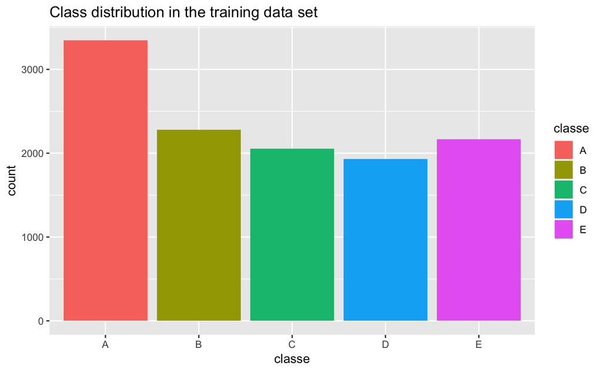

```r
df.train %>% ggplot() +
    geom_bar(aes(classe, fill=classe)) +
    ggtitle("Class distribution in the training data set")
```

The classe variable has 5 unique values (A to E). There is no severe class imbalance.

## Missing values

```r
# df.train %>% select(colnames(df.train)[colSums(is.na(df.train)) > 0])
df.train %>%
    #select_if(function(x) any(is.na(x))) %>%
    summarise_all(funs(sum(is.na(.)))) %>%
    gather(key="column.name", value="number.of.na") %>%
    count(number.of.na) %>%
    mutate(precentage.of.na = round(number.of.na/NROW(df.train)*100, 2))
```

| number.of.na | n | precentage.of.na |
| --- | --- | --- |
| 0 | 53 | 0.00 |
| 11528 | 91 | 97.89 |
| 11529 | 1 | 97.90 |
| 11530 | 1 | 97.91 |
| 11531 | 1 | 97.92 |
| 11532 | 4 | 97.93 |
| 11579 | 1 | 98.33 |
| 11580 | 1 | 98.34 |

Out of all 153 columns, 100 columns do contain missing values. The columns with missing values are almost exclusively filled with missing values (sparse). Hence all columns with missing values are dropped. The classe variable contains no NAs.

```r
# exclude columns with NA values
df.train.na <- df.train %>%
    select_if(function(x) !any(is.na(x)))
```

## Zero variance variables

```r
nearZeroVar(df.train.na)
```

```
integer(0)
```

There are no near zero variance variables.

## Prinicpal component analysis

The training data set has 11776 rows and 53 columns. First tests have shown that the training time can get quite large. To reduce the training time the number of columns is reduced with prinicipal component analysis.

```r
preProcValues <- preProcess(df.train.na,
                            method = c("center", "scale", "pca"),
                            thresh = 0.90)
preProcValues
```

```
Created from 11776 samples and 53 variables

Pre-processing:
  - centered (52)
  - ignored (1)
  - principal component signal extraction (52)
  - scaled (52)

PCA needed 18 components to capture 90 percent of the variance
```

```r
df.train.na.pca <- predict(preProcValues, df.train.na)
```

# Model training

We have learned from the lectures, that bagging, boosting, random forest or combinations thereof are among the most successful algorithms at kaggle competitions. Hence we will try and compare these advanced models in the project.

Olson et al. [1] compare 13 models on 164 datasets for classification. They recommend gradient boosting, random forest, support vector classifier, extra trees classifier and logistic regression as a starting point for model selection.

In this study lda, random forest, SVM (polynomial kernel & radial kernel) and gradient boosted trees are used and compared. Cross-validation is used to tune the models and to chose the best model.

```r
trControl <- trainControl(method="repeatedcv", number=5, repeats=1,
                          allowParallel = TRUE,
                          verboseIter = TRUE)

data <- df.train.na.pca

set.seed(18)
model.lda <- train(classe~., data=data, method="lda", trControl=trControl)
set.seed(18)
model.svmL <- train(classe~., data=data, method="svmLinear", trControl=trControl)
set.seed(18)
model.svmR <- train(classe~., data=data, method="svmRadial", trControl=trControl)
set.seed(18)
model.svmP <- train(classe~., data=data, method="svmPoly", trControl=trControl)
set.seed(18)
model.prf <- train(classe~., data=data, method="parRF", trControl=trControl)
set.seed(18)
model.gbm <- train(classe~., data=data, method="gbm", trControl=trControl, verbose = FALSE)
```

# Model evaluation

## Model selection

```r
results <- resamples(list(LDA = model.lda,
                          SVML = model.svmL,
                          SVMR = model.svmR,
                          SVMP = model.svmP,
                          PRF = model.prf,
                          GBM = model.gbm))
summary(results, metric = "Accuracy")
```

```
Call:
summary.resamples(object = results, metric = "Accuracy")

Models: LDA, SVML, SVMR, SVMP, PRF, GBM
Number of resamples: 5

Accuracy
          Min.   1st Qu.    Median      Mean   3rd Qu.      Max. NA's
LDA  0.4842954 0.4953311 0.4989384 0.4960951 0.4991504 0.5027601    0
SVML 0.5110357 0.5293118 0.5343803 0.5319307 0.5401274 0.5447983    0
SVMR 0.8479184 0.8505942 0.8518047 0.8548739 0.8573854 0.8666667    0
SVMP 0.9469440 0.9481733 0.9537155 0.9523605 0.9562818 0.9566879    0
PRF  0.9498726 0.9524416 0.9567063 0.9566906 0.9613752 0.9630573    0
GBM  0.7867460 0.7911715 0.7923567 0.7933073 0.7940552 0.8022071    0
```

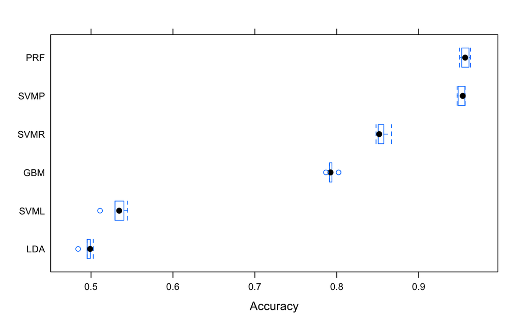

```r
bwplot(results, metric = "Accuracy")
```

## Train final model

The random forest method has the highest cross-validated accuracy out of the 6 tested models. Since the accuracy is well above 90 % no further models are tested. The final model is trained and tuned using the non-pca-data.

```r
trControl <- trainControl(method="repeatedcv", number=5, repeats=1,
                          allowParallel = TRUE,
                          verboseIter = TRUE)
set.seed(18)
model.prf2 <- train(classe~., data=df.train.na, method="parRF",
                    trControl=trControl,
                    tuneLength = 10)
```

```r
model.prf2
```

```
Parallel Random Forest

11776 samples
   52 predictor
    5 classes: 'A', 'B', 'C', 'D', 'E'

No pre-processing
Resampling: Cross-Validated (5 fold, repeated 1 times)
Summary of sample sizes: 9421, 9420, 9421, 9422, 9420
Resampling results across tuning parameters:

  mtry  Accuracy   Kappa
   2    0.9880259  0.9848518
   7    0.9905736  0.9880753
  13    0.9904037  0.9878606
  18    0.9902341  0.9876456
  24    0.9880262  0.9848528
  29    0.9877714  0.9845311
  35    0.9868374  0.9833488
  40    0.9841198  0.9799113
  46    0.9842899  0.9801245
  52    0.9811485  0.9761493

Accuracy was used to select the optimal model using the largest value.
The final value used for the model was mtry = 7.
```

```r
#results <- resamples(list(PRF2 = model.prf2), metrics = "Accuracy")
confusionMatrix.train(model.prf2)
```

```
Cross-Validated (5 fold, repeated 1 times) Confusion Matrix

(entries are percentual average cell counts across resamples)

          Reference
Prediction    A    B    C    D    E
         A 28.4  0.2  0.0  0.0  0.0
         B  0.0 19.1  0.2  0.0  0.0
         C  0.0  0.1 17.2  0.3  0.0
         D  0.0  0.0  0.0 16.1  0.1
         E  0.0  0.0  0.0  0.0 18.3

 Accuracy (average) : 0.9906
```

## Final evaluation

Preprocess the test data

```r
# the same tranformations as above have to be done for the test set
df.test.na <- df.test %>%
    select_if(function(x) !any(is.na(x)))
```

Calculate the confusion matrix

```r
confusionMatrix(predict(model.prf2, df.test.na), as.factor(df.test.na$classe))
```

```
Confusion Matrix and Statistics

          Reference
Prediction    A    B    C    D    E
         A 2230    8    0    0    0
         B    2 1508   11    0    0
         C    0    2 1354   10    3
         D    0    0    3 1275    4
         E    0    0    0    1 1435

Overall Statistics

               Accuracy : 0.9944
                 95% CI : (0.9925, 0.9959)
    No Information Rate : 0.2845
    P-Value [Acc > NIR] : < 2.2e-16

                  Kappa : 0.9929
 Mcnemar's Test P-Value : NA

Statistics by Class:

                     Class: A Class: B Class: C Class: D Class: E
Sensitivity            0.9991   0.9934   0.9898   0.9914   0.9951
Specificity            0.9986   0.9979   0.9977   0.9989   0.9998
Pos Pred Value         0.9964   0.9915   0.9890   0.9945   0.9993
Neg Pred Value         0.9996   0.9984   0.9978   0.9983   0.9989
Prevalence             0.2845   0.1935   0.1744   0.1639   0.1838
Detection Rate         0.2842   0.1922   0.1726   0.1625   0.1829
Detection Prevalence   0.2852   0.1939   0.1745   0.1634   0.1830
Balanced Accuracy      0.9988   0.9957   0.9937   0.9952   0.9975
```

From the final evaluation on the test set we estimate an out-of-sample accuracy of 99.44 % with a 95% confidence interval ranging from 99.25 % to 99.59%.

# Quiz

Calculate the answers for the extra test set.

```r
testing <- read_csv("pml-testing.csv")
```

```r
testing <- select(testing, -X1:-num_window)
# exclude columns with NA values
testing <- testing %>%
    select_if(function(x) !any(is.na(x)))
```

```r
predict(model.prf2, testing)
```

```
 [1] B A B A A E D B A A B C B A E E A B B B
Levels: A B C D E
```

**References**

[1] Olson et al., arXiv 2018, *Data-driven Advice for Applying Machine Learning to Bioinformatics Problems*, https://arxiv.org/abs/1708.05070